# Pregunta de programación. Previas a la hackatón URP

El problema descrito se puede plantear como una modificación de un problema clásico llamado **problema del agente viajero** (*TSP*). Si interpretamos a las ciudades como nodos de un grafo y las conexiones entre estos como los caminos posibles a tomar (con un costo respectivo), entonces el *TSP* busca generar una ruta de mínimo costo (en este caso, distancia) que conecte a todos los nodos del grafo, tal que cada nodo sea visitado una única vez y cuente con una única salida. La versión modificada del *TSP* que resuelve **el problema brindado** consiste en que se debe cortar el arco dirigido dentro de la solución del *TSP* que tenga el mayor costo (pues se parte de una ciudad y se finaliza en otra distinta).

Nuestro equipo reliza esto mediante **programación lineal** con la librería **docplex** de Python.

Primero se debe instalar **IBM ILOG Optimization Studio** desde [acá](https://www.ibm.com/pe-es/products/ilog-cplex-optimization-studio). Luego de ello, leer la documentación de **docplex** que incluye instrucciones de instalación [acá](https://github.com/IBMDecisionOptimization/docplex-examples)

```python
# Todas las liberías necesarias:
from docplex.mp.model import Model # importando la clase 'Model' de Programación Lineal
import numpy as np # álgebra lineal
import pandas as pd # DataFrames para manipular tablas de datos
import networkx as nx
```

```python
# Carga de archivo txt:
lista_data = []
with open('rutas.txt') as file:
    todas_lineas = file.readlines()
    for linea in todas_lineas:
        lista_temp = []
        loc_to = linea.find(" to ")
        loc_igual = linea.find(" = ")
        lista_temp.append(linea[0:loc_to]) # origen
        lista_temp.append(linea[loc_to+4:loc_igual]) # destino
        lista_temp.append(float(linea[loc_igual+3:][:-1])) # distancia eliminando el '\n'
        lista_data.append(lista_temp)

print(lista_data)
```

```
[['AlphaCentauri', 'Snowdin', 66.0], ['AlphaCentauri', 'Tambi', 28.0], ['AlphaCentauri', 'Faerun', 60.0], ['AlphaCentauri', 'Norrath', 34.0], ['AlphaCentauri', 'Straylight', 34.0], ['AlphaCentauri', 'Tristram', 3.0], ['AlphaCentauri', 'Arbre', 108.0], ['Snowdin', 'Tambi', 22.0], ['Snowdin', 'Faerun'…
```

```python
# Dataframe con la información:
dataframe_arcos = pd.DataFrame(lista_data)
dataframe_arcos.head()
```

|  | 0 | 1 | 2 |
| --- | --- | --- | --- |
| 0 | AlphaCentauri | Snowdin | 66.0 |
| 1 | AlphaCentauri | Tambi | 28.0 |
| 2 | AlphaCentauri | Faerun | 60.0 |
| 3 | AlphaCentauri | Norrath | 34.0 |
| 4 | AlphaCentauri | Straylight | 34.0 |

```python
# Extraemos las etiquetas de ciudades:
ciudades_unicas = list(set(np.hstack((dataframe_arcos[0], dataframe_arcos[1]))))
ciudades_unicas.sort()
ciudades_unicas
```

```
['AlphaCentauri',
 'Arbre',
 'Faerun',
 'Norrath',
 'Snowdin',
 'Straylight',
 'Tambi',
 'Tristram']
```

```python
# Creamos matriz de distancias:
matriz_dist = pd.DataFrame(data = np.full(shape=(len(ciudades_unicas), len(ciudades_unicas)), fill_value = 999999),
                           index = ciudades_unicas,
                           columns = ciudades_unicas)

# Rellenamos la matriz con las distancias correctas:
for row in dataframe_arcos.iterrows():
    orig = row[1][0]
    dest = row[1][1]
    dist = row[1][2]
    matriz_dist.loc[orig, dest] = dist

matriz_dist # vemos matriz finalizada!
```

|  | AlphaCentauri | Arbre | Faerun | Norrath | Snowdin | Straylight | Tambi | Tristram |
| --- | --- | --- | --- | --- | --- | --- | --- | --- |
| AlphaCentauri | 999999 | 108.0 | 60.0 | 34.0 | 66.0 | 34.0 | 28.0 | 3.0 |
| Arbre | 999999 | 999999.0 | 999999.0 | 999999.0 | 999999.0 | 999999.0 | 999999.0 | 999999.0 |
| Faerun | 999999 | 83.0 | 999999.0 | 63.0 | 999999.0 | 21.0 | 999999.0 | 57.0 |
| Norrath | 999999 | 60.0 | 999999.0 | 999999.0 | 999999.0 | 9.0 | 999999.0 | 50.0 |
| Snowdin | 999999 | 71.0 | 12.0 | 91.0 | 999999.0 | 121.0 | 22.0 | 111.0 |
| Straylight | 999999 | 81.0 | 999999.0 | 999999.0 | 999999.0 | 999999.0 | 999999.0 | 27.0 |
| Tambi | 999999 | 40.0 | 39.0 | 113.0 | 999999.0 | 130.0 | 999999.0 | 35.0 |
| Tristram | 999999 | 9.0 | 999999.0 | 999999.0 | 999999.0 | 999999.0 | 999999.0 | 999999.0 |

Abajo modelamos las restricciones de la formulación TSP de Tucker-Miller-Zemlin (1960), desde su paper *"Integer Programming Formulation of Traveling Salesman Problems"*

```python
def ModeloTSP(dataframe_distancias, etiquetas_nodos, str_nombre_modelo):
    """
    Devuelve un objeto 'Model' de CPLEX que resuelve el TSP con la formulación propuesta por Tucker-Miller-Zemlin.
    """
    # Creamos nuestra instancia del modelo:
    m = Model(name = str_nombre_modelo)

    cantidad_nodos = len(etiquetas_nodos)

    ## Parámetros del modelo:
    # SET's:
    indices_nodos = etiquetas_nodos.copy()

    # VAR's:
    # Lo de abajo se llama comprensión de diccionario! Nótese que eliminamos todos los i==j, ahorrando variables y tiempo
    x = {(i,j): m.binary_var(name='x_{0}_{1}'.format(i,j)) for i in indices_nodos for j in indices_nodos if i!=j}
    u = {i: m.integer_var(name='u_{0}'.format(i)) for i in indices_nodos}

    # Función Objetivo:
    m.minimize(
        m.sum(
            x[i,j] * dataframe_distancias.loc[i,j] for i in indices_nodos for j in indices_nodos if i!=j
        )
    )

    ## RESTRICCIONES:
    # Entrada:
    for j in indices_nodos:
        m.add_constraint(m.sum(x[i,j] for i in indices_nodos if i!=j) == 1,
                         ctname='entrada_{0}'.format(j))

    # Salida:
    for i in indices_nodos:
        m.add_constraint(m.sum(x[i,j] for j in indices_nodos if i!=j) == 1,
                         ctname='salida_{0}'.format(i))

    # Subtours:
    for i in indices_nodos[1:]: # tomamos a partir del segundo indice (empieza en '0')
        for j in indices_nodos[1:]: # tomamos a partir del segundo indice (empieza en '0')
            if i!=j:
                m.add_constraint(u[i] - u[j] + cantidad_nodos * x[i,j] <= cantidad_nodos - 1,
                                 ctname='subtour_{0}_{1}'.format(i, j))

    print(m.print_information())

    return m


def ObtenerMatrizViajes(dataframe_distancias, etiquetas_nodos, modelo_resuelto):
    """
    Obtenemos la matriz de viajes, el cual es el resultado del modelo TSP Tucker-Miller-Zemlin.
    """
    # Obtenemos las conexiones a modo de lista:
    conexiones = list(
        map(
            lambda x: tuple(x.split('_')),
            [
                i[2:] for i in list(modelo_resuelto.solution.as_dict().keys()) if i[0] == 'x' # magia!
            ]
        )
    )

    # Construimos la matriz binaria de conexiones:
    matriz_conexiones = pd.DataFrame(data=np.zeros_like(dataframe_distancias.copy().values),
                                     index=etiquetas_nodos,
                                     columns=etiquetas_nodos)
    for i,j in conexiones:
        matriz_conexiones.loc[i,j] = 1

    return matriz_conexiones
```

```python
# Creando el modelo:
modelo_tsp_hacka = ModeloTSP(dataframe_distancias=matriz_dist,
                         etiquetas_nodos=ciudades_unicas,
                         str_nombre_modelo='TSP_hackaton_URP')
```

```
Model: TSP_hackaton_URP
 - number of variables: 64
   - binary=56, integer=8, continuous=0
 - number of constraints: 58
   - linear=58
 - parameters: defaults
None
```

```python
# Resolviendo el modelo:
modelo_tsp_hacka.solve(log_output=True)
print("============================ SOLUCIÓN ============================")
modelo_tsp_hacka.print_solution()
```

```
CPXPARAM_Read_DataCheck                          1
Tried aggregator 1 time.
MIP Presolve eliminated 0 rows and 1 columns.
Reduced MIP has 58 rows, 63 columns, and 238 nonzeros.
Reduced MIP has 56 binaries, 7 generals, 0 SOSs, and 0 indicators.
Presolve time = 0.00 sec. (0.12 ticks)
Probing time = 0.00 sec. (0.08 ticks)
Tried aggregator 1 time.
Reduced MIP has 58 rows, 63 columns, and 238 nonzeros.
Reduced MIP has 56 binaries, 7 generals, 0 SOSs, and 0 indicators.
Presolve time = 0.00 sec. (0.16 ticks)
Probing time = 0.00 sec. (0.09 ticks)
Clique table members: 37.
MIP emphasis: balance optimality and feasibility.
MIP search method: dynamic search.
Parallel mode: deterministic, using up to 8 threads.
Root relaxation solution time = 0.00 sec. (0.09 ticks)

        Nodes                                         Cuts/
   Node  Left     Objective  IInf  Best Integer    Best Bound    ItCnt     Gap

*     0     0      integral     0  1000234.0000  1000234.0000       10    0.00%
Elapsed time = 0.03 sec. (1.00 ticks, tree = 0.00 MB, solutions = 1)

Root node processing (before b&c):
  Real time             =    0.03 sec. (1.00 ticks)
Parallel b&c, 8 threads:
  Real time             =    0.00 sec. (0.00 ticks)
  Sync time (average)   =    0.00 sec.
  Wait time (average)   =    0.00 sec.
                          ------------
Total (root+branch&cut) =    0.03 sec. (1.00 ticks)
============================ SOLUCIÓN ============================
objective: 1000234.000
  x_AlphaCentauri_Snowdin=1
  x_Arbre_AlphaCentauri=1
  x_Faerun_Norrath=1
  x_Norrath_Straylight=1
  x_Snowdin_Tambi=1
  x_Straylight_Tristram=1
  x_Tambi_Faerun=1
  x_Tristram_Arbre=1
  u_Arbre=6
  u_Faerun=2
  u_Norrath=3
  u_Straylight=4
  u_Tambi=1
  u_Tristram=5
```

```python
# Obtenemos la matriz de recorridos:
viajes_tsp_hacka = ObtenerMatrizViajes(dataframe_distancias=matriz_dist,
                                      etiquetas_nodos=ciudades_unicas,
                                      modelo_resuelto=modelo_tsp_hacka)

respuesta_parcial = viajes_tsp_hacka * matriz_dist # distancia por conexión
respuesta_parcial
```

|  | AlphaCentauri | Arbre | Faerun | Norrath | Snowdin | Straylight | Tambi | Tristram |
| --- | --- | --- | --- | --- | --- | --- | --- | --- |
| AlphaCentauri | 0.0 | 0.0 | 0.0 | 0.0 | 66.0 | 0.0 | 0.0 | 0.0 |
| Arbre | 999999.0 | 0.0 | 0.0 | 0.0 | 0.0 | 0.0 | 0.0 | 0.0 |
| Faerun | 0.0 | 0.0 | 0.0 | 63.0 | 0.0 | 0.0 | 0.0 | 0.0 |
| Norrath | 0.0 | 0.0 | 0.0 | 0.0 | 0.0 | 9.0 | 0.0 | 0.0 |
| Snowdin | 0.0 | 0.0 | 0.0 | 0.0 | 0.0 | 0.0 | 22.0 | 0.0 |
| Straylight | 0.0 | 0.0 | 0.0 | 0.0 | 0.0 | 0.0 | 0.0 | 27.0 |
| Tambi | 0.0 | 0.0 | 39.0 | 0.0 | 0.0 | 0.0 | 0.0 | 0.0 |
| Tristram | 0.0 | 9.0 | 0.0 | 0.0 | 0.0 | 0.0 | 0.0 | 0.0 |

Para finalizar el ejercicio, basta con remover el arco más largo. En este caso, termina siendo el arco que contiene una conexión que no debería ser posible (999999 de Arbre a AlphaCentauri)

```python
mascara = respuesta_parcial == (respuesta_parcial.max().max())
respuesta_final = respuesta_parcial
respuesta_final[mascara] = 0

respuesta_final #la respuesta final!
```

|  | AlphaCentauri | Arbre | Faerun | Norrath | Snowdin | Straylight | Tambi | Tristram |
| --- | --- | --- | --- | --- | --- | --- | --- | --- |
| AlphaCentauri | 0.0 | 0.0 | 0.0 | 0.0 | 66.0 | 0.0 | 0.0 | 0.0 |
| Arbre | 0.0 | 0.0 | 0.0 | 0.0 | 0.0 | 0.0 | 0.0 | 0.0 |
| Faerun | 0.0 | 0.0 | 0.0 | 63.0 | 0.0 | 0.0 | 0.0 | 0.0 |
| Norrath | 0.0 | 0.0 | 0.0 | 0.0 | 0.0 | 9.0 | 0.0 | 0.0 |
| Snowdin | 0.0 | 0.0 | 0.0 | 0.0 | 0.0 | 0.0 | 22.0 | 0.0 |
| Straylight | 0.0 | 0.0 | 0.0 | 0.0 | 0.0 | 0.0 | 0.0 | 27.0 |
| Tambi | 0.0 | 0.0 | 39.0 | 0.0 | 0.0 | 0.0 | 0.0 | 0.0 |
| Tristram | 0.0 | 9.0 | 0.0 | 0.0 | 0.0 | 0.0 | 0.0 | 0.0 |

```python
print('Longitud óptima: ', respuesta_final.sum().sum())
```

```
Longitud óptima:  235.0
```

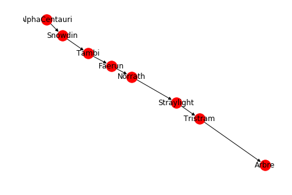

```python
# Visualizamos la respuesta final:
G = nx.from_pandas_adjacency(respuesta_final, create_using=nx.MultiDiGraph()) # grafo dirigido!
nx.draw(G, with_labels=True)
```